# Module-5 Project-1

Angel_Lopez_Bellmont

January 10, 2016

## 1.Code for reading in the dataset and/or processing the data

I point to my workingdirectory, and I control if the dataSet activity.csv is already read or not

```r
library(lubridate)
library(timeDate)
library(stringr)
library(plyr)
library(dplyr)
```

```r
library(ggplot2)
setwd("C:/2015.07.31_Angel/00Angel/SoftwareProgramsCursosIT/Coursera/2016.01.06-Mod5_ReproducibleResearch/Mod5_Proj_1")
#here I control that the file is read only when it is not been already read
if(!exists("myData"))
{
  mypath_toFile_csv <-  paste("C:/2015.07.31_Angel/00Angel/SoftwareProgramsCursosIT/Coursera/2016.01.06-Mod5_ReproducibleResearch",
                              "/Mod5_Proj_1/activity.csv", sep="")

  myData  <-  read.csv(file=mypath_toFile_csv,  header=TRUE, sep=",")
  head (myData)
}
```

```
##   steps       date interval
## 1    NA 2012-10-01        0
## 2    NA 2012-10-01        5
## 3    NA 2012-10-01       10
## 4    NA 2012-10-01       15
## 5    NA 2012-10-01       20
## 6    NA 2012-10-01       25
```

```r
stepsPerDay <- aggregate (steps ~ date, myData, sum, na.rm = TRUE)
head(stepsPerDay)
```

```
##         date steps
## 1 2012-10-02   126
## 2 2012-10-03 11352
## 3 2012-10-04 12116
## 4 2012-10-05 13294
## 5 2012-10-06 15420
## 6 2012-10-07 11015
```

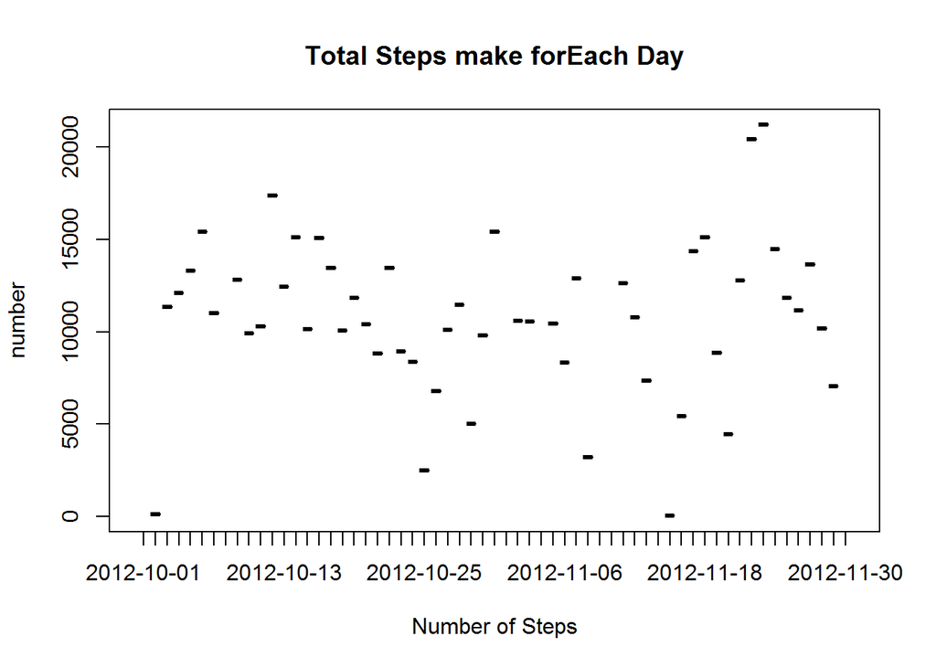

```r
#png ("stepsPerDay_Total.png", height = 500, width = 500)
plot (stepsPerDay$date, stepsPerDay$steps, type ="l",  main = "Total Steps make forEach Day", xlab = "Number of Steps", ylab="number")
```

```r
#graphics.off()
```

## 3.mean and median

Here we calculate the mean and median

```r
stepsPerDayMean <- mean (stepsPerDay$steps)
stepsPerDayMedian <- median (stepsPerDay$steps)

stepsPerDayMean
```

```
## [1] 10766.19
```

```r
stepsPerDayMedian
```

```
## [1] 10765
```

## 4.Time series plot of the average number of steps taken

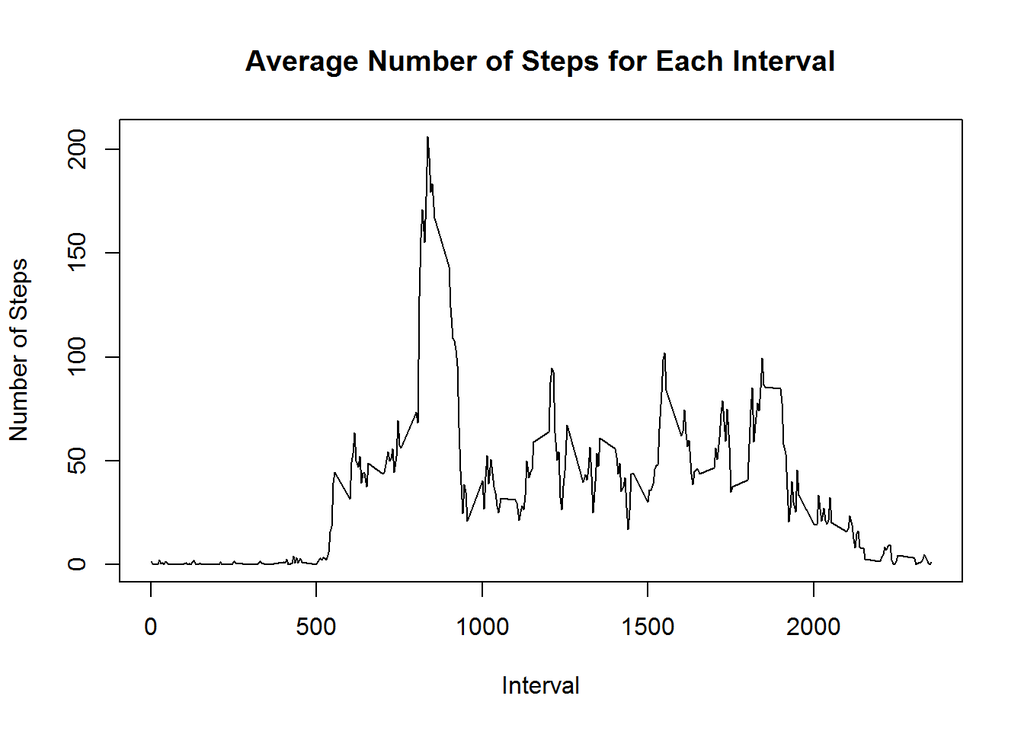

```r
stepsMeanEachInterval <- aggregate (steps ~ interval, myData, mean)

plot (stepsMeanEachInterval$interval, stepsMeanEachInterval$steps
  ,type = "l"
  ,xlab = "Interval",
  ,ylab = "Number of Steps"
  ,main = "Average Number of Steps for Each Interval")
```

```r
#No me deja pintar con qplot pq dice que tiene NA el dataSet.
# qplot (stepsMeanEachInterval$interval, stepsMeanEachInterval$steps
# ,type = "line"
# ,xlab = "Interval",
# ,ylab = "Number of Steps"
# ,main = "Average Number of Steps for Each Interval")
```

## 5. The 5-minute interval that, on average, contains the maximum number of steps

```r
  intervalMaxStep <- stepsMeanEachInterval [which.max(stepsMeanEachInterval$steps), 1]
  intervalMaxStep
```

```
## [1] 835
```

## 6. Code to describe and show a strategy for imputing missing data

We change the NA of each interval in the dataSet, for the mean value for that interval. I run all myData each row and if it's NA and I put the mean value for that interval in case there is a NA. The new data set I call it myData_2.

```r
  newColumnSteps <- numeric ()

  for (i in 1:nrow (myData))
{
     row_i <- myData [i, ]

    if (is.na (row_i$steps))
    {
       stepsNew <- subset (stepsMeanEachInterval, interval == row_i$interval)$steps
    }
    else
    {
      stepsNew <- row_i$steps
    }

  newColumnSteps <- c (newColumnSteps, stepsNew)
}

# we create the new DataSet myData_2
myData_2 <- myData
myData_2$steps <- newColumnSteps

head(myData_2)
```

```
##       steps       date interval
## 1 1.7169811 2012-10-01        0
## 2 0.3396226 2012-10-01        5
## 3 0.1320755 2012-10-01       10
## 4 0.1509434 2012-10-01       15
## 5 0.0754717 2012-10-01       20
## 6 2.0943396 2012-10-01       25
```

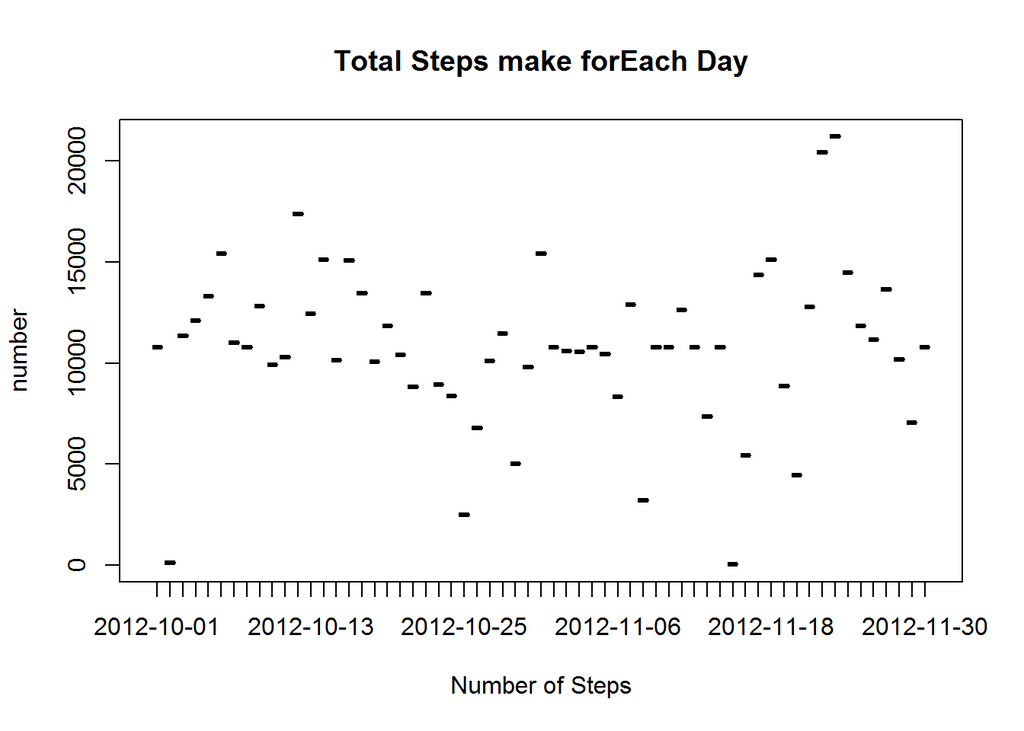

```r
stepsPerDay_2 <- aggregate (steps ~ date, myData_2, sum, na.rm = TRUE)
plot(stepsPerDay_2$date, stepsPerDay_2$steps
     , type = "line"
     , main = "Total Steps make forEach Day"
     , xlab = "Number of Steps"
     , ylab="number")
```

```r
# qplot(stepsPerDay_2$date, stepsPerDay_2$steps
#      , type = "line"
#      , main = "Total Steps make forEach Day"
#      , xlab = "Number of Steps"
#      , ylab="number")


#plot (stepsMeanEachInterval$interval, stepsMeanEachInterval$steps, type = "l", main = "main", xlab = "Interval", ylab = "Number of Steps")
```

I have to transfor the original dataset myDate, the date colum into date.

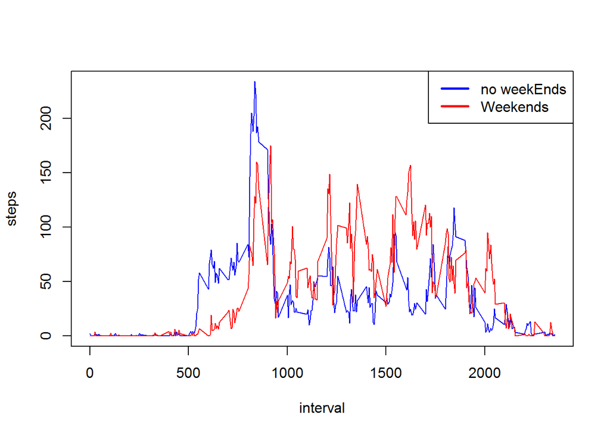

```r
myData$date <- as.Date(myData$date, "%Y-%m-%d")

day <- weekdays (myData$date)
daytype <- vector ()

  for (i in 1:nrow (myData))
  {
    if (day [i] == "Saturday")
    {
      daytype [i] <- "weekend"
    }
    else if (day [i] == "Sunday")
    {
      daytype [i] <- "weekend"
    }
    else
    {
      daytype [i] <- "weekday"
    }
  }

myData$daytype <- daytype
myData$daytype <- factor (myData$daytype)



myDataWeek <- aggregate (steps ~ interval + daytype, myData, mean)
names(myDataWeek) <- c ("interval", "daytype", "steps")

noWeekEnd <- subset (myDataWeek, daytype=="weekday")
weekEnd <- subset (myDataWeek, daytype=="weekend")

plot (noWeekEnd$interval, noWeekEnd$steps, type ="l" , col="blue",  xlab="interval", ylab="steps")
lines (  weekEnd$interval,   weekEnd$steps, type ="l", col="red")
legend("topright", c("no weekEnds", "Weekends"), lty=1, lwd=2.5, col=c("blue", "red"))
```